# DS202 Homework 7

Scott Madland, On Wave Tiong

2023-03-27

Team members:On Wave Tiong, Scott Madland.

Link to github repo: https://github.com/Towave28/Homework-7.

```r
library(tidyverse)
HAPPY <- readRDS("data/HAPPY.rds")
head(HAPPY)
```

```
##           HAPPY YEAR AGE    SEX       MARITAL         DEGREE       FINRELA
## 1 NOT TOO HAPPY 1972  23 FEMALE NEVER MARRIED       BACHELOR       AVERAGE
## 2 NOT TOO HAPPY 1972  70   MALE       MARRIED LT HIGH SCHOOL ABOVE AVERAGE
## 3  PRETTY HAPPY 1972  48 FEMALE       MARRIED    HIGH SCHOOL       AVERAGE
## 4 NOT TOO HAPPY 1972  27 FEMALE       MARRIED       BACHELOR       AVERAGE
## 5  PRETTY HAPPY 1972  61 FEMALE       MARRIED    HIGH SCHOOL ABOVE AVERAGE
## 6  PRETTY HAPPY 1972  26   MALE NEVER MARRIED    HIGH SCHOOL ABOVE AVERAGE
##      HEALTH WTSSALL          PARTYID POLVIEWS
## 1      GOOD  0.4446     IND,NEAR DEM      IAP
## 2      FAIR  0.8893 NOT STR DEMOCRAT      IAP
## 3 EXCELLENT  0.8893      INDEPENDENT      IAP
## 4      GOOD  0.8893 NOT STR DEMOCRAT      IAP
## 5      GOOD  0.8893  STRONG DEMOCRAT      IAP
## 6      GOOD  0.4446     IND,NEAR DEM      IAP
```

Data cleaning: the values “IAP”, “DK” and “NA” all encode missing values. Replace all of these instances by the value NA.

```r
HAPPY<-na_if(HAPPY,"IAP")
HAPPY<-na_if(HAPPY,"DK")
HAPPY<-na_if(HAPPY,"NA")
```

Check the type of the variable and cast into the right type (factor variable for categorical variables). For age, change “89 OR OLDER” to 89 and assume the variable should be numeric.

```r
str(HAPPY)
```

```
## 'data.frame':    62466 obs. of  11 variables:
##  $ HAPPY   : chr  "NOT TOO HAPPY" "NOT TOO HAPPY" "PRETTY HAPPY" "NOT TOO HAPPY" ...
##  $ YEAR    : int  1972 1972 1972 1972 1972 1972 1972 1972 1972 1972 ...
##  $ AGE     : chr  "23" "70" "48" "27" ...
##  $ SEX     : chr  "FEMALE" "MALE" "FEMALE" "FEMALE" ...
##  $ MARITAL : chr  "NEVER MARRIED" "MARRIED" "MARRIED" "MARRIED" ...
##  $ DEGREE  : chr  "BACHELOR" "LT HIGH SCHOOL" "HIGH SCHOOL" "BACHELOR" ...
##  $ FINRELA : chr  "AVERAGE" "ABOVE AVERAGE" "AVERAGE" "AVERAGE" ...
##  $ HEALTH  : chr  "GOOD" "FAIR" "EXCELLENT" "GOOD" ...
##  $ WTSSALL : num  0.445 0.889 0.889 0.889 0.889 ...
##  $ PARTYID : chr  "IND,NEAR DEM" "NOT STR DEMOCRAT" "INDEPENDENT" "NOT STR DEMOCRAT" ...
##  $ POLVIEWS: chr  NA NA NA NA ...
```

```r
HAPPY$HAPPY<-factor(HAPPY$HAPPY)
HAPPY$SEX<-factor(HAPPY$SEX)
HAPPY$MARITAL<-factor(HAPPY$MARITAL)
HAPPY$DEGREE<-factor(HAPPY$DEGREE)
HAPPY$FINRELA<-factor(HAPPY$FINRELA)
HAPPY$HEALTH<-factor(HAPPY$HEALTH)
HAPPY$PARTYID<-factor(HAPPY$PARTYID)
HAPPY$POLVIEWS<-factor(HAPPY$POLVIEWS)
HAPPY$AGE<-as.numeric(HAPPY$AGE)
levels(HAPPY$HAPPY)
```

```
## [1] "NOT TOO HAPPY" "PRETTY HAPPY"  "VERY HAPPY"
```

```r
levels(HAPPY$SEX)
```

```
## [1] "FEMALE" "MALE"
```

```r
levels(reorder(HAPPY$MARITAL, HAPPY$AGE, na.rm=TRUE))
```

```
## [1] "NEVER MARRIED" "SEPARATED"     "MARRIED"       "DIVORCED"
## [5] "WIDOWED"
```

```r
levels(factor(HAPPY$DEGREE,
              levels=c("LT HIGH SCHOOL", "HIGH SCHOOL",
                     "JUNIOR COLLEGE", "BACHELOR",
                     "GRADUATE")
              )
       )
```

```
## [1] "LT HIGH SCHOOL" "HIGH SCHOOL"    "JUNIOR COLLEGE" "BACHELOR"
## [5] "GRADUATE"
```

```r
levels(factor(HAPPY$FINRELA,
              levels=c("FAR BELOW AVERAGE", "BELOW AVERAGE",
                     "AVERAGE", "ABOVE AVERAGE",
                     "FAR ABOVE AVERAGE")
              )
       )
```

```
## [1] "FAR BELOW AVERAGE" "BELOW AVERAGE"     "AVERAGE"
## [4] "ABOVE AVERAGE"     "FAR ABOVE AVERAGE"
```

```r
levels(factor(HAPPY$HEALTH,
              levels=c("POOR", "FAIR",
                     "GOOD", "EXCELLENT")
              )
       )
```

```
## [1] "POOR"      "FAIR"      "GOOD"      "EXCELLENT"
```

```r
levels(factor(HAPPY$PARTYID,
              levels=c("STRONG DEMOCRAT", "NOT STR DEMOCRAT", "IND,NEAR DEM","INDEPENDENT",
                     "IND,NEAR REP", "NOT STR REPUBLICAN","STRONG REPUBLICAN",
                     "OTHER PARTY")
              )
       )
```

```
## [1] "STRONG DEMOCRAT"    "NOT STR DEMOCRAT"   "IND,NEAR DEM"
## [4] "INDEPENDENT"        "IND,NEAR REP"       "NOT STR REPUBLICAN"
## [7] "STRONG REPUBLICAN"  "OTHER PARTY"
```

```r
levels(factor(HAPPY$POLVIEWS,
              levels=c("EXTREMELY LIBERAL", "LIBERAL", "SLIGHTLY LIBERAL","MODERATE",
                     "SLIGHTLY CONSERVATIVE", "CONSERVATIVE","EXTREMLY CONSERVATIVE")
              )
       )
```

```
## [1] "EXTREMELY LIBERAL"     "LIBERAL"               "SLIGHTLY LIBERAL"
## [4] "MODERATE"              "SLIGHTLY CONSERVATIVE" "CONSERVATIVE"
## [7] "EXTREMLY CONSERVATIVE"
```

```r
saveRDS
```

[output not shown]

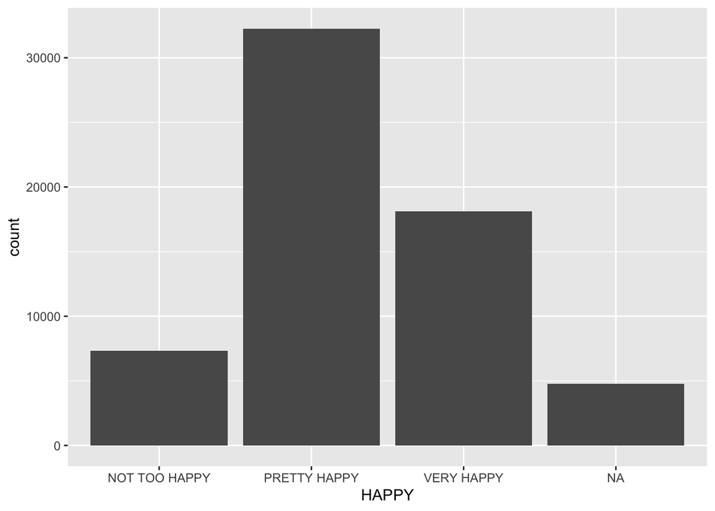

```r
ggplot(HAPPY, aes(x = HAPPY)) +
  geom_bar(na.rm=TRUE)
```

Pretty happy is the most common choice according to this chart.

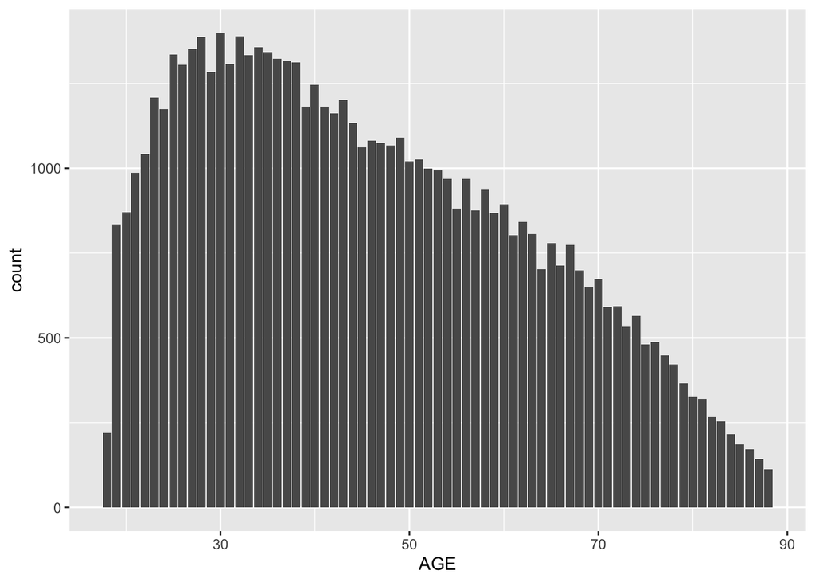

```r
ggplot(HAPPY, aes(x = AGE)) +
  geom_bar(na.rm=TRUE)
```

It seems that the age chart is right skewed and most people that took the survey is about 29 years old.

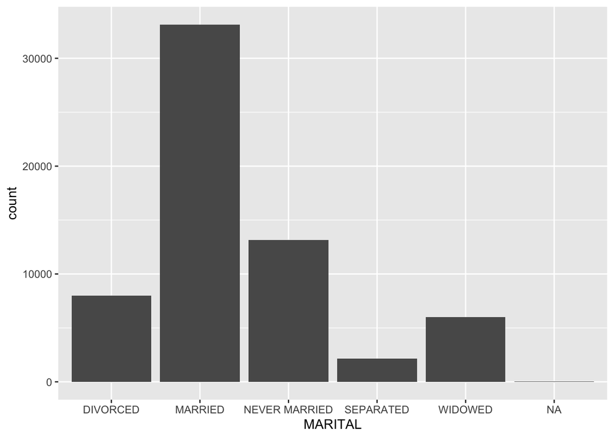

```r
ggplot(HAPPY, aes(x = MARITAL)) +
  geom_bar(na.rm=TRUE)
```

Most people that answered the survey are married.

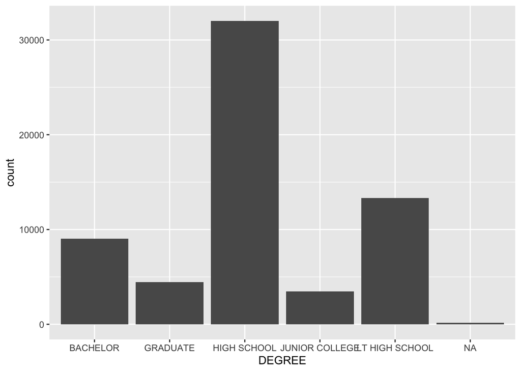

```r
ggplot(HAPPY, aes(x = DEGREE)) +
  geom_bar(na.rm=TRUE)
```

Most people that answered the survey are in high school.

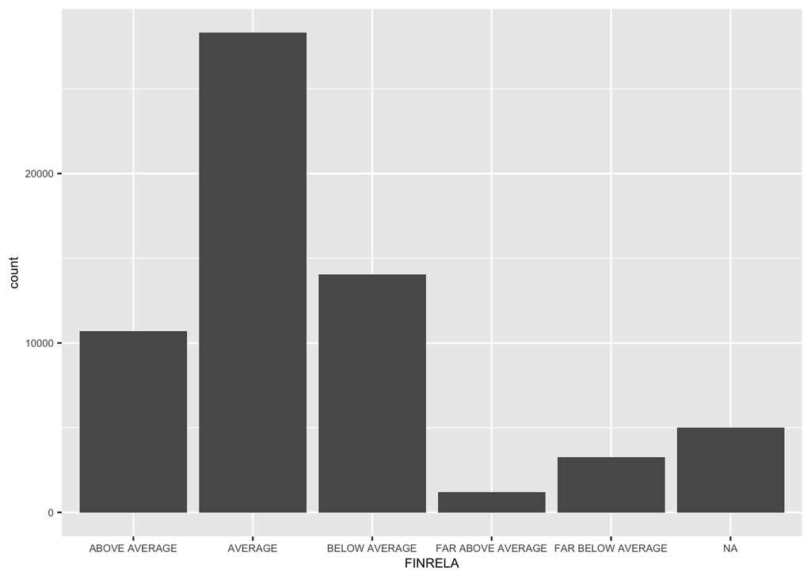

```r
ggplot(HAPPY, aes(x = FINRELA)) +
  geom_bar(na.rm=TRUE) + theme(text=element_text(size=8))
```

The most common family income in the US seems to be average.

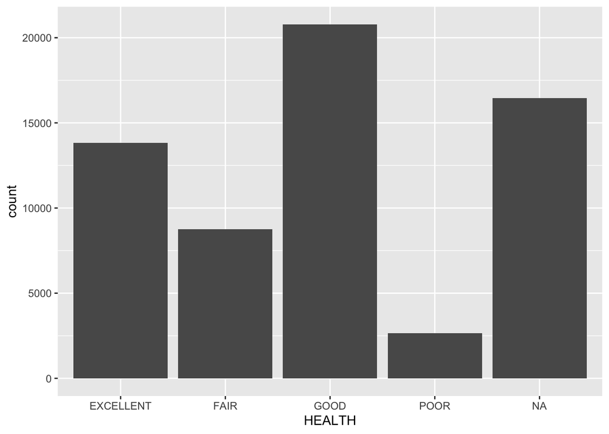

```r
ggplot(HAPPY, aes(x = HEALTH)) +
  geom_bar(na.rm=TRUE)
```

The most people that answered this survey seems to be in good health.

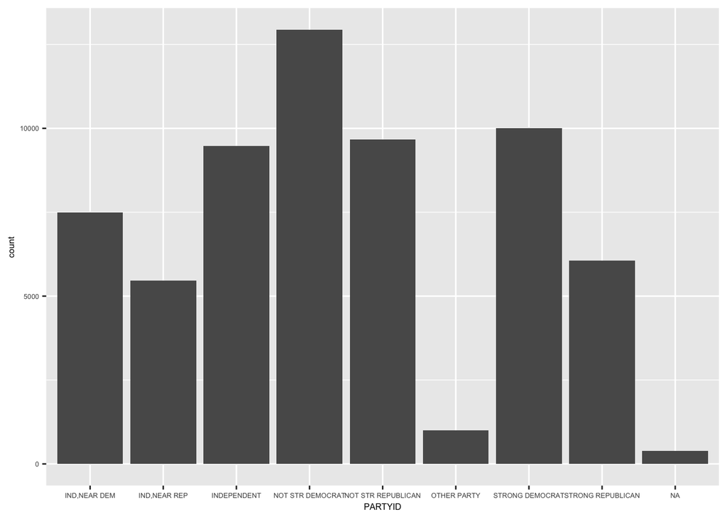

```r
ggplot(HAPPY, aes(x = PARTYID)) +
  geom_bar(na.rm=TRUE) +theme(text=element_text(size=6))
```

The most people that answered this survey are not strong democrat.

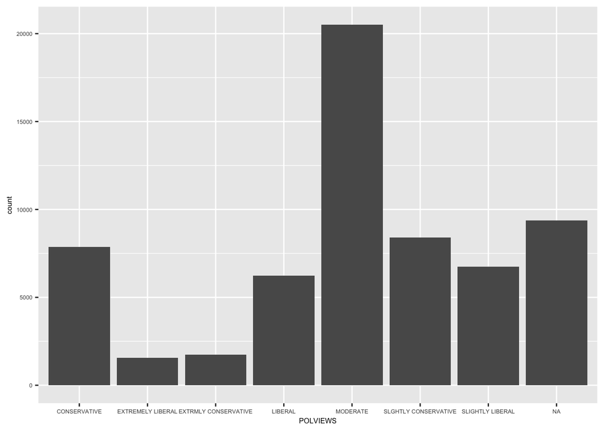

```r
ggplot(HAPPY, aes(x = POLVIEWS)) +
  geom_bar(na.rm=TRUE) +theme(text=element_text(size=6))
```

The most people that answered this survey has a moderate political view.

Question from On Wave Tiong:  
How is the health situation of male or female in the US.

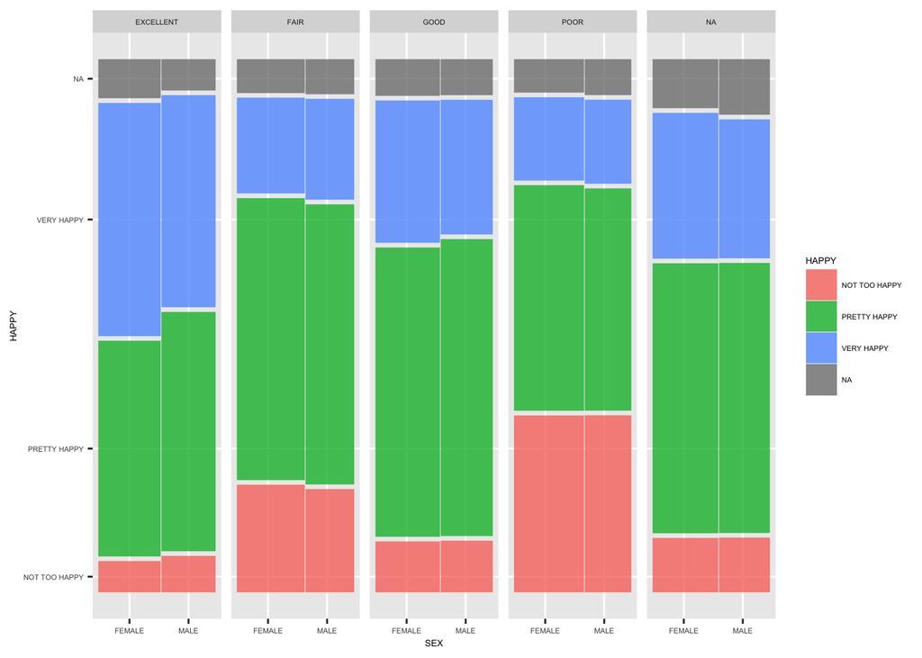

```r
library(ggmosaic)
ggplot(data = HAPPY)  +
  geom_mosaic(aes(x = product(SEX), fill=HAPPY, weight=1)) +
  facet_grid(.~HEALTH) +theme(text=element_text(size=5))
```

Question for Scott Madland:  
What is the distribution across ages and what can we take away?

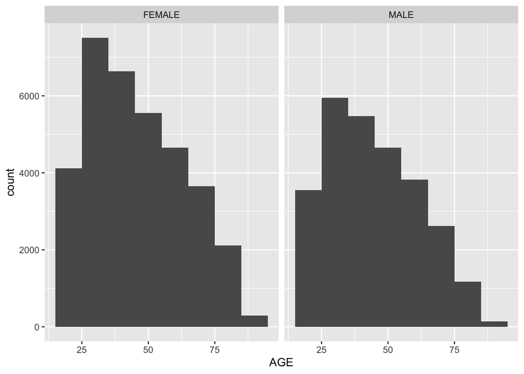

```r
library(ggmosaic)
ggplot(data = HAPPY , aes(x = AGE)) +
  geom_histogram(binwidth=10) +
  facet_grid(~SEX)
```

We can conclude that the distribution of ages is right skewed. Late 20s makes up the most populated age group. And unsurprisingly the least populated age group is the oldest. There are also more females as opposed to males. The distribution among genders ia relatively similar.